# Personal Information

Name: **Ioana Mazilu**

StudentID: **14642484**

Email: **ioana.mazilu@student.uva.nl**

Submitted on: **18.03.2024**

# Data Context

**The aim of my research project is to test the ability of base and fine-tuned language models (small - 7B/13B and large 1.76T parameters) to generate Python scripts that can perform calculations and comparisons and return the correct classification label for a pair of premise and hypothesis. This task is known as Quantitative Natural Language Inference (QNLI), and it is derived from the NLI task, but focuses only on sentences with quantitative information.**

**The dataset I will be using is called EQUATE, which is a benchmark dataset for QNLI, introduced by Ravichander et al. [1]. It consists of 5 sub-datasets, with various characteristics. Three of the datasets are of natural-language source (NewsNLI - from news articles, RedditNLI - from financial headlines on Reddit, and RTE_Quant - from a dataset for numerical reasoning). The other 2 datasets are of synthetic nature (AWPNLI - derived from math word problems, and StressTest, derived from algebra word problems). The datasets consist of a premise, hypothesis and label, which is one of entailment, contradiction or neutral. There are other features as well in the datasets, created from processing of the premise/hypothesis features. However, for my project only the former-named columns are relevant. For the EDA, we will also take a look at some of the other columns.**

The code related to this project is stored at https://github.com/IoanaMazilu/msc_qnli

**References**

[1] References Ravichander, A., Naik, A., Rosé, C. P., & Hovy, E. H. (2019). EQUATE: A Benchmark Evaluation Framework for Quantitative Reasoning in Natural Language Inference. CoRR, abs/1901.03735. Retrieved from http://arxiv.org/abs/1901.03735

# Data description

**At the level of EQUATE, there is also an imbalance, as StressTest has over 7K samples, while all other datasets have less than 1K samples, and RTE_Quant even less than 200:**

- RedditNLI: 2.58%
- NewsNLI: 9.98%
- RTE_Quant: 1.71%
- AWPNLI: 7.44%
- StressTest: 78.29%

**By looking at the length of the premise and hypothesis, we observe that some datasets have almost equal-length premises and hypotheses. We assume this is because the focus is on a direct comparison of the quantities in the inputs and/or identifying if the hypothesis is not related to the premise (which is usually the neutral class). Conversely, for the sets where the hypothesis is much shorter than the premise, we observe that the former is usually a shorter, rephrased version of the latter (2 or 3 times shorter). We also find that AWPNLI involves calculations using the quantities in the premise, obtaining a final value which must be compared to the one in the hypothesis.**

**Using word-clouds to inspect the most frequent unigrams at both the premise and hypothesis level also reveals some interesting insights about the topics covered in the datasets and what types of quantities can be found inside them. For instance, AWPNLI (derived from math word problems) contains a lot of simple nouns (i.e., orange, apple, dimes, books etc.) and verbs indicating either addition or subtraction (picked, left, bought, needed). This also suggests that samples in this dataset will require calculations before a comparison can be made to infer the QNLI label.**

```python
import jsonlines
import os
import re

import numpy as np
import pandas as pd
```

```python
# go back 2 directories from the cwd
root_path = os.path.dirname(os.path.dirname(os.getcwd()))
data_directory_path = os.path.join(root_path, "data", "equate")
```

### Data Loading

```python
def read_data(filename):
    ''' Reads a jsonl file
    :param filename: file to be read
    :return: list of NLI samples
    '''
    print(f"###############\nData file: {filename.split('/')[-1]}")
    samples = []
    with jsonlines.open(os.path.join(data_directory_path, filename)) as reader:
        for obj in reader:
            samples.append(obj)
    assert len(samples) > 0
    labels = set([sample['gold_label'] for sample in samples]) # unique labels in the dataset
    samples_df = pd.DataFrame(samples)
    samples_df["sample_index"] = samples_df.index
    samples_df = samples_df.rename(columns={"sentence1": "premise", "sentence2": "hypothesis", "gold_label": "label", "sentence1_pos": "premise_pos", "sentence2_pos": "hypothesis_pos"})
    print(f"Dataset features: {samples_df.columns}")
    return samples_df, labels
```

```python
datasets = ["AWPNLI.jsonl", "NewsNLI.jsonl", "RedditNLI.jsonl", "RTE_Quant.jsonl", "StressTest.jsonl"]
datasets = [os.path.join(data_directory_path, dataset) for dataset in datasets]

awp, awp_labels = read_data(datasets[0])
news, news_labels = read_data(datasets[1])
reddit, reddit_labels = read_data(datasets[2])
rte, rte_labels = read_data(datasets[3])
stress, stress_labels = read_data(datasets[4])
```

```
###############
Data file: AWPNLI.jsonl
Dataset features: Index(['sentence2_tokens', 'sentence1_dep_parse', 'sentence1_binary_parse',
       'sentence2_binary_parse', 'sentence1_syntax_parse', 'premise',
       'hypothesis', 'sentence2_syntax_parse', 'hypothesis_pos',
       'sentence2_dep_parse', 'label', 'premise_pos', 'sentence1_tokens',
       'sample_index'],
      dtype='object')
###############
Data file: NewsNLI.jsonl
Dataset features: Index(['sentence2_tokens', 'annotator_labels', 'sentence1_tokens',
       'sentence1_dep_parse', 'sentence2_syntax_parse', 'Phenomena',
       'sentence1_binary_parse', 'Hard', 'sentence2_parse',
       'sentence2_binary_parse', 'sentence1_syntax_parse', 'premise',
       'hypothesis', 'sentence1_parse', 'genre', 'hypothesis_pos',
       'sentence2_dep_parse', 'label', 'premise_pos', 'PairID',
       'sample_index'],
      dtype='object')
###############
Data file: RedditNLI.jsonl
Dataset features: Index(['sentence2_tokens', 'sentence1_tokens', 'sentence1_dep_parse',
       'sentence2_syntax_parse', 'sentence1_binary_parse', 'sentence2_parse',
       'sentence2_binary_parse', 'sentence1_syntax_parse', 'premise',
       'hypothesis', 'sentence1_parse', 'genre', 'hypothesis_pos',
       'sentence2_dep_parse', 'label', 'premise_pos', 'PairID',
       'sample_index'],
      dtype='object')
###############
Data file: RTE_Quant.jsonl
Dataset features: Index(['sentence2_tokens', 'annotator_labels', 'sentence1_dep_parse',
       'sentence1_binary_parse', 'sentence2_binary_parse',
       'sentence1_syntax_parse', 'premise', 'hypothesis',
       'sentence2_syntax_parse', 'genre', 'hypothesis_pos',
       'sentence2_dep_parse', 'label', 'premise_pos', 'sentence1_tokens',
       'sample_index'],
      dtype='object')
###############
Data file: StressTest.jsonl
Dataset features: Index(['sentence2_tokens', 'sentence1_dep_parse', 'sentence1_binary_parse',
       'sentence2_binary_parse', 'sentence1_syntax_parse', 'premise',
       'hypothesis', 'sentence2_syntax_parse', 'hypothesis_pos',
       'sentence2_dep_parse', 'label', 'premise_pos', 'sentence1_tokens',
       'sample_index'],
      dtype='object')
```

#### We notice some of the datasets have unique features (i.e. RTE_Quant has a 'genre' feature, NewsNLI has a 'genre', 'Hard', 'Phenomena' and 'annotator_labels'. We will inspect these features later to find out what they represent.

#### Explanation of the columns, relevant for the EDA:

- premise: the premise
- hypothesis: the hypothesis
- label: the NLI classification label (entailment/neutral/contradiction)
- premise_pos, hypothesis_pos: For each sentence in the premise/hypothesis, a list is extracted of the role of each word in the sentence. Example: For the sentence "15.0 pizzas were served today", the following list of word roles is extracted: [["CD", "NNS", "VBD", "VBN", "NN"]]. We observe that "CD" represents quantities.

```python
awp.head(5)
```

|  | sentence2_tokens | sentence1_dep_parse | sentence1_binary_parse | sentence2_binary_parse | sentence1_syntax_parse | premise | hypothesis | sentence2_syntax_parse | hypothesis_pos | sentence2_dep_parse | label | premise_pos | sentence1_tokens | sample_index |
| --- | --- | --- | --- | --- | --- | --- | --- | --- | --- | --- | --- | --- | --- | --- |
| 0 | [[sam, has, 16.0, dimes, now]] | [[{'dep': 'ROOT', 'dependent': 11, 'governorGl... | Sam had 9.0 dimes in his bank and his dad gav... | Sam has 16.0 dimes now | [(ROOT\n (NP\n (S\n (S\n (NP (... | Sam had 9.0 dimes in his bank and his dad gav... | Sam has 16.0 dimes now | [(ROOT\n (S\n (NP (NN sam))\n (VP (VBZ ... | [[NN, VBZ, CD, NNS, RB]] | [[{'dep': 'ROOT', 'dependent': 2, 'governorGlo... | entailment | [[NN, VBD, CD, NNS, IN, PRP$, NN, CC, PRP$, NN... | [[sam, had, 9.0, dimes, in, his, bank, and, hi... | 0 |
| 1 | [[sam, has, 17.0, dimes, now]] | [[{'dep': 'ROOT', 'dependent': 11, 'governorGl... | Sam had 9.0 dimes in his bank and his dad gav... | Sam has 17.0 dimes now | [(ROOT\n (NP\n (S\n (S\n (NP (... | Sam had 9.0 dimes in his bank and his dad gav... | Sam has 17.0 dimes now | [(ROOT\n (S\n (NP (NN sam))\n (VP (VBZ ... | [[NN, VBZ, CD, NNS, RB]] | [[{'dep': 'ROOT', 'dependent': 2, 'governorGlo... | contradiction | [[NN, VBD, CD, NNS, IN, PRP$, NN, CC, PRP$, NN... | [[sam, had, 9.0, dimes, in, his, bank, and, hi... | 1 |
| 2 | [[15.0, pizzas, were, served, today]] | [[{'dep': 'ROOT', 'dependent': 3, 'governorGlo... | A restaurant served 9.0 pizzas during lunch an... | 15.0 pizzas were served today | [(ROOT\n (S\n (NP (DT a) (NN restaurant))\... | A restaurant served 9.0 pizzas during lunch an... | 15.0 pizzas were served today | [(ROOT\n (S\n (NP (CD 15.0) (NNS pizzas))\... | [[CD, NNS, VBD, VBN, NN]] | [[{'dep': 'ROOT', 'dependent': 4, 'governorGlo... | entailment | [[DT, NN, VBD, CD, NNS, IN, NN, CC, CD, IN, NN... | [[a, restaurant, served, 9.0, pizzas, during, ... | 2 |
| 3 | [[17.0, pizzas, were, served, today]] | [[{'dep': 'ROOT', 'dependent': 3, 'governorGlo... | A restaurant served 9.0 pizzas during lunch an... | 17.0 pizzas were served today | [(ROOT\n (S\n (NP (DT a) (NN restaurant))\... | A restaurant served 9.0 pizzas during lunch an... | 17.0 pizzas were served today | [(ROOT\n (S\n (NP (CD 17.0) (NNS pizzas))\... | [[CD, NNS, VBD, VBN, NN]] | [[{'dep': 'ROOT', 'dependent': 4, 'governorGlo... | contradiction | [[DT, NN, VBD, CD, NNS, IN, NN, CC, CD, IN, NN... | [[a, restaurant, served, 9.0, pizzas, during, ... | 3 |
| 4 | [[5.0, pencils, are, now, there, in, total]] | [[{'dep': 'ROOT', 'dependent': 2, 'governorGlo... | There are 2.0 pencils in the drawer and Tim p... | 5.0 pencils are now there in total | [(ROOT\n (S\n (NP (EX there))\n (VP (VB... | There are 2.0 pencils in the drawer and Tim p... | 5.0 pencils are now there in total | [(ROOT\n (S\n (NP (CD 5.0) (NNS pencils))\... | [[CD, NNS, VBP, RB, RB, IN, NN]] | [[{'dep': 'ROOT', 'dependent': 5, 'governorGlo... | entailment | [[EX, VBP, CD, NNS, IN, DT, NN, CC, NN, VBD, C... | [[there, are, 2.0, pencils, in, the, drawer, a... | 4 |

### Analysis of sample counts per sub-dataset in EQUATE and per language type (natural/synthetic)

#### How many samples are in each dataset?

```python
print(len(awp), len(news), len(reddit), len(rte), len(stress))
```

```
722 968 250 166 7596
```

#### What fraction of the EQUATE benchmark each sub-dataset is?

```python
equate_size = len(awp) + len(news) + len(reddit) + len(rte) + len(stress)
print(round(len(awp)*100/equate_size, 2), round(len(news)*100/equate_size, 2), round(len(reddit)*100/equate_size, 2), round(len(rte)*100/equate_size, 2), round(len(stress)*100/equate_size, 2))
```

```
7.44 9.98 2.58 1.71 78.29
```

The datasets are of 2 types:

- based on natural, every-day language, scraped from sources like Reddit (RedditNLI), news articles (NewsNLI) and a dataset of quantitative problems (RTE_Quant);
- based on synthetic language, created from Math World Problems (MWPs) (StressTest, AWPNLI). Let's inspect how many samples of each category we have

```python
natural_language_samples = news.shape[0] + reddit.shape[0] + rte.shape[0]
synthetic_language_samples = stress.shape[0] + awp.shape[0]
total_samples = natural_language_samples + synthetic_language_samples
print(f"Natural-language samples: {natural_language_samples} ({round((natural_language_samples/total_samples)*100, 2)}% of all samples in EQUATE)")
print(f"Synthetic-language samples: {synthetic_language_samples} ({round((synthetic_language_samples/total_samples)*100, 2)}% of all samples in EQUATE)")
```

```
Natural-language samples: 1384 (14.27% of all samples in EQUATE)
Synthetic-language samples: 8318 (85.73% of all samples in EQUATE)
```

#### We notice a significant imbalance at the EQUATE dataset level between natural language samples and synthetic language samples, with a large ratio of the total samples being of synthetic nature, and more specifically from the StressTest dataset.

### Analysis of the sentences which form the premises and hypotheses.

UTIL FUNCTIONS

```python
def clean_text(df: pd.DataFrame, column_name: str):
    df[column_name] = df[column_name].apply(lambda str_value: re.sub(r'\s+', ' ', str_value.replace("\n", "")).strip())
```

```python
def count_words_in_string(df: pd.DataFrame, column_name: str):
    df[f"{column_name}_word_cnt"] = df[column_name].apply(lambda str_value: len(str_value.split(" ")))
```

```python
def count_chars_in_string(df: pd.DataFrame, column_name: str):
    df[f"{column_name}_char_cnt"] = df[column_name].apply(lambda str_value: len(str_value))
```

```python
def quantities_in_sentence(df: pd.DataFrame, column_name: str):
    df[f"{column_name}_quantities_cnt"] = df[f"{column_name}_pos"].apply(lambda entities: np.sum([1 for i in range(len(entities)) for entity in entities[i] if entity == "CD"]))
```

```python
def unique_annotator_labels(df: pd.DataFrame):
    df["annotator_unique_labels"] = df["annotator_labels"].apply(lambda labels_array: len(set(labels_array)))
```

```python
def sentence_insights(dataset_df):
    clean_text(dataset_df, "premise")
    clean_text(dataset_df, "hypothesis")
    count_words_in_string(dataset_df, "premise")
    count_words_in_string(dataset_df, "hypothesis")
    count_chars_in_string(dataset_df, "premise")
    count_chars_in_string(dataset_df, "hypothesis")
    quantities_in_sentence(dataset_df, "premise")
    quantities_in_sentence(dataset_df, "hypothesis")
    if "annotator_labels" in dataset_df.columns:
        unique_annotator_labels(dataset_df)
    else:
        print("There is no data on the annotator labels for this dataset.")
```

#### AWPNLI dataset

```python
awp.head()
```

|  | sentence2_tokens | sentence1_dep_parse | sentence1_binary_parse | sentence2_binary_parse | sentence1_syntax_parse | premise | hypothesis | sentence2_syntax_parse | hypothesis_pos | sentence2_dep_parse | label | premise_pos | sentence1_tokens | sample_index |
| --- | --- | --- | --- | --- | --- | --- | --- | --- | --- | --- | --- | --- | --- | --- |
| 0 | [[sam, has, 16.0, dimes, now]] | [[{'dep': 'ROOT', 'dependent': 11, 'governorGl... | Sam had 9.0 dimes in his bank and his dad gav... | Sam has 16.0 dimes now | [(ROOT\n (NP\n (S\n (S\n (NP (... | Sam had 9.0 dimes in his bank and his dad gav... | Sam has 16.0 dimes now | [(ROOT\n (S\n (NP (NN sam))\n (VP (VBZ ... | [[NN, VBZ, CD, NNS, RB]] | [[{'dep': 'ROOT', 'dependent': 2, 'governorGlo... | entailment | [[NN, VBD, CD, NNS, IN, PRP$, NN, CC, PRP$, NN... | [[sam, had, 9.0, dimes, in, his, bank, and, hi... | 0 |
| 1 | [[sam, has, 17.0, dimes, now]] | [[{'dep': 'ROOT', 'dependent': 11, 'governorGl... | Sam had 9.0 dimes in his bank and his dad gav... | Sam has 17.0 dimes now | [(ROOT\n (NP\n (S\n (S\n (NP (... | Sam had 9.0 dimes in his bank and his dad gav... | Sam has 17.0 dimes now | [(ROOT\n (S\n (NP (NN sam))\n (VP (VBZ ... | [[NN, VBZ, CD, NNS, RB]] | [[{'dep': 'ROOT', 'dependent': 2, 'governorGlo... | contradiction | [[NN, VBD, CD, NNS, IN, PRP$, NN, CC, PRP$, NN... | [[sam, had, 9.0, dimes, in, his, bank, and, hi... | 1 |
| 2 | [[15.0, pizzas, were, served, today]] | [[{'dep': 'ROOT', 'dependent': 3, 'governorGlo... | A restaurant served 9.0 pizzas during lunch an... | 15.0 pizzas were served today | [(ROOT\n (S\n (NP (DT a) (NN restaurant))\... | A restaurant served 9.0 pizzas during lunch an... | 15.0 pizzas were served today | [(ROOT\n (S\n (NP (CD 15.0) (NNS pizzas))\... | [[CD, NNS, VBD, VBN, NN]] | [[{'dep': 'ROOT', 'dependent': 4, 'governorGlo... | entailment | [[DT, NN, VBD, CD, NNS, IN, NN, CC, CD, IN, NN... | [[a, restaurant, served, 9.0, pizzas, during, ... | 2 |
| 3 | [[17.0, pizzas, were, served, today]] | [[{'dep': 'ROOT', 'dependent': 3, 'governorGlo... | A restaurant served 9.0 pizzas during lunch an... | 17.0 pizzas were served today | [(ROOT\n (S\n (NP (DT a) (NN restaurant))\... | A restaurant served 9.0 pizzas during lunch an... | 17.0 pizzas were served today | [(ROOT\n (S\n (NP (CD 17.0) (NNS pizzas))\... | [[CD, NNS, VBD, VBN, NN]] | [[{'dep': 'ROOT', 'dependent': 4, 'governorGlo... | contradiction | [[DT, NN, VBD, CD, NNS, IN, NN, CC, CD, IN, NN... | [[a, restaurant, served, 9.0, pizzas, during, ... | 3 |
| 4 | [[5.0, pencils, are, now, there, in, total]] | [[{'dep': 'ROOT', 'dependent': 2, 'governorGlo... | There are 2.0 pencils in the drawer and Tim p... | 5.0 pencils are now there in total | [(ROOT\n (S\n (NP (EX there))\n (VP (VB... | There are 2.0 pencils in the drawer and Tim p... | 5.0 pencils are now there in total | [(ROOT\n (S\n (NP (CD 5.0) (NNS pencils))\... | [[CD, NNS, VBP, RB, RB, IN, NN]] | [[{'dep': 'ROOT', 'dependent': 5, 'governorGlo... | entailment | [[EX, VBP, CD, NNS, IN, DT, NN, CC, NN, VBD, C... | [[there, are, 2.0, pencils, in, the, drawer, a... | 4 |

```python
awp['label'].value_counts(normalize=True)
```

```
label
entailment       0.5
contradiction    0.5
Name: proportion, dtype: float64
```

The distribution of samples across the 2 labels is balanced

```python
sentence_insights(awp)

awp[["premise", "hypothesis", "label", "premise_word_cnt", "hypothesis_word_cnt", "premise_char_cnt", "hypothesis_char_cnt"]].head()
```

```
There is no data on the annotator labels for this dataset.
```

|  | premise | hypothesis | label | premise_word_cnt | hypothesis_word_cnt | premise_char_cnt | hypothesis_char_cnt |
| --- | --- | --- | --- | --- | --- | --- | --- |
| 0 | Sam had 9.0 dimes in his bank and his dad gave... | Sam has 16.0 dimes now | entailment | 14 | 5 | 60 | 22 |
| 1 | Sam had 9.0 dimes in his bank and his dad gave... | Sam has 17.0 dimes now | contradiction | 14 | 5 | 60 | 22 |
| 2 | A restaurant served 9.0 pizzas during lunch an... | 15.0 pizzas were served today | entailment | 13 | 5 | 73 | 29 |
| 3 | A restaurant served 9.0 pizzas during lunch an... | 17.0 pizzas were served today | contradiction | 13 | 5 | 73 | 29 |
| 4 | There are 2.0 pencils in the drawer and Tim pl... | 5.0 pencils are now there in total | entailment | 15 | 7 | 76 | 34 |

```python
awp[["premise_word_cnt", "hypothesis_word_cnt", "premise_char_cnt", "hypothesis_char_cnt"]].aggregate(["mean", "std"])
```

|  | premise_word_cnt | hypothesis_word_cnt | premise_char_cnt | hypothesis_char_cnt |
| --- | --- | --- | --- | --- |
| mean | 16.236842 | 6.450139 | 84.925208 | 33.279778 |
| std | 5.694548 | 1.919570 | 32.652246 | 10.538450 |

We notice that the premises are larger than the hypotheses, on average, by at least 2 times. By looking at some examples of premise and hypothesis pairs, we notice that for this dataset, the hypothesis is a summary of the premise, with respect to the quantities, while the premise is longer as it presents more quantities. We can deduce that for the AWPNLI, there will always be a calculation needed between the quantities in the premise, before a comparison can be made to infer the label.

#### Let's check for duplicates in the dataset, at a premise-hypothesis pair level. Do these duplicates have the same label? If not, which is the pair with the correct label?

```python
awp[awp.duplicated(subset=["premise", "hypothesis"])].shape[0]
```

```
0
```

```python
# Turn the premise and hypothesis to lowercase, to ensure we do a case-insensitive check for duplicates as well
awp["premise_lower"] = awp["premise"].str.lower()
awp["hypothesis_lower"] = awp["hypothesis"].str.lower()

awp[awp.duplicated(subset=["premise_lower", "hypothesis_lower"])].shape[0]
```

```
0
```

#### Let's inspect the frequency of quantities in the dataset premises and hypotheses

```python
awp[["premise_quantities_cnt", "hypothesis_quantities_cnt"]].aggregate(["mean", "std", "min", "max"])
```

|  | premise_quantities_cnt | hypothesis_quantities_cnt |
| --- | --- | --- |
| mean | 2.234072 | 1.034626 |
| std | 0.561652 | 0.229980 |
| min | 1.000000 | 0.000000 |
| max | 4.000000 | 2.000000 |

```python
awp[awp["hypothesis_quantities_cnt"] == 0][["premise", "hypothesis", "hypothesis_pos"]]
```

|  | premise | hypothesis | hypothesis_pos |
| --- | --- | --- | --- |
| 52 | Each of farmer Cunningham 's 6048.0 lambs is e... | 5855.0 of Farmer Cunningham 's lambs are black | [[NN, IN, NN, NN, POS, NNS, VBP, JJ]] |
| 53 | Each of farmer Cunningham 's 6048.0 lambs is e... | 5854.0 of Farmer Cunningham 's lambs are black | [[NN, IN, NN, NN, POS, NNS, VBP, JJ]] |
| 54 | A treasure hunter discovered a buried treasure... | 5110.0 of the gems were rubies | [[NN, IN, DT, NNS, VBD, NNS]] |
| 55 | A treasure hunter discovered a buried treasure... | 5108.0 of the gems were rubies | [[NN, IN, DT, NNS, VBD, NNS]] |
| 188 | Randy has 78.0 blocks and he uses 19.0 blocks ... | 59.0 blocks are left | [[NN, NNS, VBP, VBN]] |
| 532 | There was 698.0 children taking a test and 105... | 593.0 children had to sit it again | [[JJ, NNS, VBD, TO, VB, PRP, RB]] |
| 533 | There was 698.0 children taking a test and 105... | 591.0 children had to sit it again | [[JJ, NNS, VBD, TO, VB, PRP, RB]] |

Notice that sometimes the role of words is not extracted properly. These sentences seem to have 1 quantity, so the hypotheses have between 1 and 2 quantities, while the premises have between 1 and 4 quantities.

#### Let's check if the dataset contains features which are not in all datasets

```python
awp.columns
```

```
Index(['sentence2_tokens', 'sentence1_dep_parse', 'sentence1_binary_parse',
       'sentence2_binary_parse', 'sentence1_syntax_parse', 'premise',
       'hypothesis', 'sentence2_syntax_parse', 'hypothesis_pos',
       'sentence2_dep_parse', 'label', 'premise_pos', 'sentence1_tokens',
       'sample_index', 'premise_word_cnt', 'hypothesis_word_cnt',
       'premise_char_cnt', 'hypothesis_char_cnt', 'premise_quantities_cnt',
       'hypothesis_quantities_cnt', 'premise_lower', 'hypothesis_lower'],
      dtype='object')
```

There are no extra features in this dataset to analyze.

#### NewsNLI dataset

```python
news.head()
```

|  | sentence2_tokens | annotator_labels | sentence1_tokens | sentence1_dep_parse | sentence2_syntax_parse | Phenomena | sentence1_binary_parse | Hard | sentence2_parse | sentence2_binary_parse | ... | premise | hypothesis | sentence1_parse | genre | hypothesis_pos | sentence2_dep_parse | label | premise_pos | PairID | sample_index |
| --- | --- | --- | --- | --- | --- | --- | --- | --- | --- | --- | --- | --- | --- | --- | --- | --- | --- | --- | --- | --- | --- |
| 0 | [[joey, lepore, says, he, took, photos, of, on... | [entailment, entailment, entailment, neutral, ... | [[lepore, said, he, was, moved, to, photograph... | [[{'dep': 'ROOT', 'dependent': 2, 'governorGlo... | [(ROOT\n (S\n (NP (NN joey) (NN lepore))\n... | [] | ( ( ( Lepore ) ) ( ( said ) ( ( ( ( he ) ) ( (... | Yes | (S (NP (NNP Joey) (NNP Lepore)) (VP (VBZ says)... | ( ( ( Joey ) ( Lepore ) ) ( ( says ) ( ( ( ( h... | ... | Lepore said he was moved to photograph the slu... | Joey Lepore says he took photos of one guard s... | (S (NP (NNP Lepore)) (VP (VBD said) (SBAR (S (... | News | [[NN, NN, VBZ, PRP, VBD, NNS, IN, CD, NN, VBG,... | [[{'dep': 'ROOT', 'dependent': 3, 'governorGlo... | entailment | [[NN, VBD, PRP, VBD, VBN, TO, NN, DT, JJ, NNS,... | 27 | 0 |
| 1 | [[darren, sharper, has, been, charged, in, two... | [neutral, entailment, entailment, entailment, ... | [[sharper, ,, 38, ,, faces, rape, charges, in,... | [[{'dep': 'ROOT', 'dependent': 5, 'governorGlo... | [(ROOT\n (S\n (NP\n (NP (NN darren))\... | [Implicit quantity, Arithmetic] | ( ( ( ( ( Sharper ) ) (, , ) ( ( 38 ) ) (, , )... | Yes | (S (NP (NNP Darren) (NNP Sharper)) (VP (VBZ ha... | ( ( ( Darren ) ( Sharper ) ) ( ( has ) ( ( bee... | ... | Sharper , 38 , faces rape charges in Arizona a... | Darren Sharper has been charged in two states ... | (S (S (NP (NP (JJR Sharper)) (, ,) (NP (CD 38)... | News | [[NN, JJR, VBZ, VBN, VBN, IN, CD, NNS, IN, DT,... | [[{'dep': 'ROOT', 'dependent': 5, 'governorGlo... | entailment | [[JJR, ,, CD, ,, VBZ, NN, NNS, IN, NN, CC, NN,... | 2670 | 1 |
| 2 | [[weldon, says, she, 's, a, single, mom, of, t... | [neutral, neutral, entailment, entailment, ent... | [[i, am, the, single, mother, of, three, sons,... | [[{'dep': 'ROOT', 'dependent': 5, 'governorGlo... | [(ROOT\n (S\n (NP (NN weldon))\n (VP (V... | [] | ( ( ( ( I ) ) ( ( am ) ( ( ( the ) ( single ) ... | Yes | (S (NP (NNP Weldon)) (VP (VBZ says) (SBAR (S (... | ( ( ( Weldon ) ) ( ( says ) ( ( ( ( she ) ) ( ... | ... | I am the single mother of three sons -- grown ... | Weldon says she 's a single mom of three flour... | (S (S (NP (PRP I)) (VP (VBP am) (NP (NP (DT th... | News | [[NN, VBZ, PRP, VBZ, DT, JJ, NN, IN, CD, VBG, ... | [[{'dep': 'ROOT', 'dependent': 2, 'governorGlo... | entailment | [[LS, VBP, DT, JJ, NN, IN, CD, NNS, :, :, VBN,... | 1401 | 2 |
| 3 | [[the, crash, took, the, lives, of, 79, people... | [neutral, entailment, entailment, entailment, ... | [[in, addition, to, 79, fatalities, ,, some, 1... | [[{'dep': 'ROOT', 'dependent': 11, 'governorGl... | [(ROOT\n (S\n (NP (DT the) (NN crash))\n ... | [] | ( ( ( In ) ( ( ( addition ) ) ( ( to ) ( ( 79 ... | Yes | (S (NP (DT The) (NN crash)) (VP (VP (VBD took)... | ( ( ( The ) ( crash ) ) ( ( ( took ) ( ( ( the... | ... | In addition to 79 fatalities , some 170 passen... | The crash took the lives of 79 people and inju... | (S (PP (IN In) (NP (NP (NN addition)) (PP (TO ... | News | [[DT, NN, VBD, DT, NNS, IN, CD, NNS, CC, VBN, ... | [[{'dep': 'ROOT', 'dependent': 3, 'governorGlo... | entailment | [[IN, NN, TO, CD, NNS, ,, DT, CD, NNS, VBD, VB... | 974 | 3 |
| 4 | [[rip, currents, kill, four, in, alabama, ,, c... | [neutral, entailment, neutral, entailment, ent... | [[treacherous, currents, took, at, least, four... | [[{'dep': 'ROOT', 'dependent': 3, 'governorGlo... | [(ROOT\n (S\n (NP (NN rip) (NNS currents))... | [] | ( ( ( Treacherous ) ( currents ) ) ( ( ( took ... | Yes | (S (NP (NNP Rip) (NNS currents)) (VP (VBP kill... | ( ( ( Rip ) ( currents ) ) ( ( kill ) ( ( four... | ... | Treacherous currents took at least four lives ... | Rip currents kill four in Alabama , close beac... | (S (NP (JJ Treacherous) (NNS currents)) (VP (V... | News | [[NN, NNS, VBP, CD, IN, NN, ,, JJ, NNS, IN, NN]] | [[{'dep': 'ROOT', 'dependent': 3, 'governorGlo... | entailment | [[JJ, NNS, VBD, IN, JJS, CD, NNS, IN, DT, NN, ... | 2464 | 4 |

5 rows × 21 columns

```python
news['label'].value_counts(normalize=True)
```

```
label
entailment    0.507231
neutral       0.492769
Name: proportion, dtype: float64
```

We observe a balanced split between the 2 labels of this dataset.

```python
sentence_insights(news)

news[["premise", "hypothesis", "label", "premise_word_cnt", "hypothesis_word_cnt", "premise_char_cnt", "hypothesis_char_cnt"]].head()
```

|  | premise | hypothesis | label | premise_word_cnt | hypothesis_word_cnt | premise_char_cnt | hypothesis_char_cnt |
| --- | --- | --- | --- | --- | --- | --- | --- |
| 0 | Lepore said he was moved to photograph the slu... | Joey Lepore says he took photos of one guard s... | entailment | 20 | 14 | 123 | 73 |
| 1 | Sharper , 38 , faces rape charges in Arizona a... | Darren Sharper has been charged in two states ... | entailment | 22 | 13 | 114 | 76 |
| 2 | I am the single mother of three sons -- grown ... | Weldon says she 's a single mom of three flour... | entailment | 17 | 16 | 78 | 85 |
| 3 | In addition to 79 fatalities , some 170 passen... | The crash took the lives of 79 people and inju... | entailment | 12 | 12 | 65 | 58 |
| 4 | Treacherous currents took at least four lives ... | Rip currents kill four in Alabama , close beac... | entailment | 23 | 11 | 128 | 60 |

```python
news[["premise_word_cnt", "hypothesis_word_cnt", "premise_char_cnt", "hypothesis_char_cnt"]].aggregate(["mean", "std"])
```

|  | premise_word_cnt | hypothesis_word_cnt | premise_char_cnt | hypothesis_char_cnt |
| --- | --- | --- | --- | --- |
| mean | 22.330579 | 11.984504 | 120.600207 | 66.581612 |
| std | 8.180754 | 2.999615 | 46.449696 | 15.740119 |

We observe that the premises are on average twice as long as the hypothesis, with respect to the number of words and characters. By inspecting some of the premise-hypothesis pairs, we notice that the hypothesis is usually a shorter, rephrased version of the premise (similar to a summary of a long sentence). However, in contrast to the AWPNLI dataset, there are not necessarily calculations that need to be done in either of the 2 sentences.

#### Let's check for duplicates in the dataset, at a premise-hypothesis pair level. Do these duplicates have the same label? If not, which is the pair with the correct label?

```python
news[news.duplicated(subset=["premise", "hypothesis"])].shape[0]
```

```
5
```

```python
news[news.duplicated(subset=["premise", "hypothesis", "label"])].shape[0]
```

```
5
```

It seems like the duplicates have the same label

```python
# Turn the premise and hypothesis to lowercase, to ensure we do a case-insensitive check for duplicates as well
news["premise_lower"] = news["premise"].str.lower()
news["hypothesis_lower"] = news["hypothesis"].str.lower()

news[news.duplicated(subset=["premise_lower", "hypothesis_lower"])].shape[0]
```

```
5
```

```python
news[news.duplicated(subset=["premise", "hypothesis"])][["premise", "hypothesis", "label"]]
```

|  | premise | hypothesis | label |
| --- | --- | --- | --- |
| 41 | Mycoskie had already started four other busine... | Blake Mycoskie had launched four other start-u... | entailment |
| 67 | Cobb declined two requests from CNN to respond... | Cobb declined two requests to speak with CNN f... | entailment |
| 151 | In fact , Wernick had only seen one zombie fil... | One of film 's writers had seen just one zombi... | entailment |
| 300 | There were no reports of serious injuries , bu... | At least 8 reported arrested , but no reports ... | entailment |
| 416 | 42 percent of homeless children are younger th... | Study says 42 percent of homeless children are... | entailment |

#### Let's inspect the frequencies of quantities in the premises and hypotheses

```python
news[["premise_quantities_cnt", "hypothesis_quantities_cnt"]].aggregate(["mean", "std", "min", "max"])
```

|  | premise_quantities_cnt | hypothesis_quantities_cnt |
| --- | --- | --- |
| mean | 1.622934 | 1.380165 |
| std | 1.033748 | 0.736196 |
| min | 0.000000 | 0.000000 |
| max | 12.000000 | 8.000000 |

```python
news_no_quantities = news[(news["premise_quantities_cnt"] == 0) | (news["hypothesis_quantities_cnt"] == 0)][["premise", "hypothesis", "sample_index"]]
news_no_quantities
```

|  | premise | hypothesis | sample_index |
| --- | --- | --- | --- |
| 94 | Shaffer : Just to be clear , I was offered the... | Shaffer was offered chance to play Jerry Seinf... | 94 |
| 127 | That inmate and the county worker were undergo... | Two of the injured were undergoing emergency s... | 127 |
| 178 | But terrarium gardens and other tiny plant pro... | Terrariums and other small plant projects are ... | 178 |
| 317 | Jiang has became a celebrity , followed by loc... | Newspaper headline hails her as '' China 's Mo... | 317 |
| 364 | '' Jeremy Lin is a marketing dream come true ,... | Lin is a '' marketing dream come true , '' one... | 364 |
| 507 | ( CNN ) -- Tony Gwynn , a Hall of Fame outfiel... | Gwynn died at 54 after a long battle with sali... | 507 |
| 513 | After they complete their sentence , the pair ... | The two Britons will be deported after they co... | 513 |
| 530 | In the latest attack , a parked motorcycle bom... | Motorcycle bomb kills six in Sunni neighborhoo... | 530 |
| 569 | ( CNET.com ) -- The HP Pavilion Media Center T... | The HP Pavilion Media Center TV m8120n retails... | 569 |
| 592 | The latest trend is theaters offering '' luxur... | Premium screening rooms offer cocktails , wine... | 592 |
| 671 | ( CNN ) -- Indonesian police are searching for... | More than 200 inmates escaped from Indonesian ... | 671 |
| 697 | While the cardinal-electors are locked in the ... | 115 cardinal-electors are gathered in the Sist... | 697 |
| 778 | Hundreds of thousands took to the streets in B... | At the height of the war , 46,000 British troo... | 778 |
| 802 | The contest rules spelled out that NASA reserv... | NASA reserves right to pick name for Node 3 | 802 |
| 810 | Tamer was at the same demonstration Hamza atte... | Tamer Mohammed al Sharey , 15 , disappeared at... | 810 |
| 875 | Bobby Jindal declared a statewide state of eme... | Florida governor declares a state of emergency... | 875 |
| 886 | The incident started after South Korean comman... | South Korea has seized the ship and its nine s... | 886 |
| 887 | The second explosion took place at a crowded b... | The earlier explosion injured 12 people at a N... | 887 |
| 894 | The British island group of Tristan da Cunha s... | The islands of Tristan da Cunha sit 1,750 mile... | 894 |
| 900 | Five service members hurt , building damaged i... | He said the attack included rockets , small ar... | 900 |
| 904 | With the Eastern Cape being so key to the coun... | The Eastern Cape provides 51 % of South Africa... | 904 |
| 909 | Stone has come up with a name for the new stat... | He has drawn plans for 13 counties to form the... | 909 |
| 911 | With a win in Dubai , Stenson would become the... | Henrik Stenson shoots an eight-under-par 64 to... | 911 |
| 919 | I 'd rather be na ve , heartfelt and hopeful t... | '' Call me na ve , '' Vedder said in website post | 919 |
| 951 | Kapoor and Eroshevich were each also charged w... | All three charged with giving '' a controlled ... | 951 |
| 960 | Armed officers were confronted by a pack of do... | Four dogs were shot by armed police officers a... | 960 |
| 967 | Sponseller graduated from The Citadel and is a... | Tom Sponseller , 61 , is head of the South Car... | 967 |

```python
news_no_quantities[["premise", "hypothesis", "sample_index"]].to_excel("NewsNLI_no_quantities.xlsx")
```

Manual inspection of these samples reveals that indeed there are no quantities in them, either in numerical or verbal format. However, if at least one of the premise or hypothesis does contain a quantity, the pair should not be discarded. These could represent "neutral" samples, where the label is not necessarily inferred on a quantitative basis, but on the lack of details in one sentence (usually the premise) to support the quantitative details in the other (usually the hypothesis).

```python
pairs_no_quantities = news[(news["premise_quantities_cnt"] == 0) & (news["hypothesis_quantities_cnt"] == 0)][["premise", "hypothesis", "sample_index"]]
pairs_no_quantities
```

|  | premise | hypothesis | sample_index |
| --- | --- | --- | --- |
| 178 | But terrarium gardens and other tiny plant pro... | Terrariums and other small plant projects are ... | 178 |
| 919 | I 'd rather be na ve , heartfelt and hopeful t... | '' Call me na ve , '' Vedder said in website post | 919 |

These 2 samples could be dropped as they do not contain any quantitative information so they are not part of the type of sentences QNLI focuses on.

#### Let's inspect the data on the annotator labels - for how many samples were there disagreements between annotators?

```python
news["annotator_unique_labels"].value_counts(normalize=True)
```

```
annotator_unique_labels
2    0.646694
1    0.351240
3    0.002066
Name: proportion, dtype: float64
```

It seems like in almost 65% of cases, there was a disagreement between the annotators. This can also indicate a higher complexity of the sentences in this dataset.

```python
news.groupby("annotator_unique_labels")["label"].value_counts(normalize=True)
```

```
annotator_unique_labels  label
1                        neutral       0.523529
                         entailment    0.476471
2                        entailment    0.523962
                         neutral       0.476038
3                        entailment    0.500000
                         neutral       0.500000
Name: proportion, dtype: float64
```

It also looks like the disagreements were almost equally split between samples from both categories.

#### Let's check if the dataset contains features which are not in all datasets

```python
news.columns
```

```
Index(['sentence2_tokens', 'annotator_labels', 'sentence1_tokens',
       'sentence1_dep_parse', 'sentence2_syntax_parse', 'Phenomena',
       'sentence1_binary_parse', 'Hard', 'sentence2_parse',
       'sentence2_binary_parse', 'sentence1_syntax_parse', 'premise',
       'hypothesis', 'sentence1_parse', 'genre', 'hypothesis_pos',
       'sentence2_dep_parse', 'label', 'premise_pos', 'PairID', 'sample_index',
       'premise_word_cnt', 'hypothesis_word_cnt', 'premise_char_cnt',
       'hypothesis_char_cnt', 'premise_quantities_cnt',
       'hypothesis_quantities_cnt', 'annotator_unique_labels', 'premise_lower',
       'hypothesis_lower'],
      dtype='object')
```

```python
news["Phenomena"] = news["Phenomena"].fillna("[]")
news["Hard"] = news["Hard"].fillna("Unknown")
```

```python
extra_columns = ["Phenomena", "Hard", "genre"]
for column in extra_columns:
    print(f"###############")
    print(news[column].value_counts())
```

```
###############
Phenomena
[]                                               461
[]                                               403
[Numeration]                                      32
[QC]                                              11
[Count]                                            8
[Implicit quantity,  Arithmetic]                   6
[Quantifiers]                                      5
[Unit conversion]                                  4
[Numeration,  Arithmetic]                          2
[Arithmetic]                                       2
[Named Set]                                        2
[Ratios]                                           2
[Named set resolution]                             2
[SETS]                                             2
[Numeration,  Unit conversion]                     2
[Ordinality]                                       2
[Quantity conversion]                              2
[Quantity conversion,  Quantifiers]                2
[Quantifiers,  Ranges]                             1
[MULIPLE]                                          1
[COUNT]                                            1
[Sets]                                             1
[Reasoning]                                        1
[Quantifiers,  Numeration]                         1
[Named set resolution,  Implicit quantity]         1
[Quantifiers,  Quantity conversion]                1
[Numeration,  Quantity conversion]                 1
[Approximation]                                    1
[Implicit quantity,  Numeration]                   1
[Multi-hop reasoning,  Quantity conversion]        1
[Arithmetic,  Numeration]                          1
[Named set resolution,  Arithmetic]                1
[Quantity conversion,  Approximation]              1
[Implicit quantity,  Arithmetic,  Numeration]      1
[Approximation,  Quantifiers]                      1
[Quantifier,  Geography]                           1
Name: count, dtype: int64
###############
Hard
Yes    507
No     461
Name: count, dtype: int64
###############
genre
News    968
Name: count, dtype: int64
```

It seems like the 'genre' column is not informative, it points to the source of the samples, namely news articles.

The 'Hard' column is of Boolean nature, it may indicate if a certain example is harder to classify (more complex), but this is only an assumption. There is no information in the original paper about this column or its meaning.

The 'Phenomena' column seems to assign categories to some of the samples, of quantitative phenomena. It would be interesting to analyze the results on the samples with Phenomena vs the samples without, to see if there is any discrepancy. The ratio of samples with phenomena is relatively low.

```python
## are 'Hard' examples the ones with 'Phenomena'?

news[news['Hard'] == 'Yes']["Phenomena"].value_counts()
```

```
Phenomena
[]                                               403
[Numeration]                                      32
[QC]                                              11
[Count]                                            8
[Implicit quantity,  Arithmetic]                   6
[Quantifiers]                                      5
[Unit conversion]                                  4
[SETS]                                             2
[Ratios]                                           2
[Named Set]                                        2
[Numeration,  Arithmetic]                          2
[Named set resolution]                             2
[Arithmetic]                                       2
[Ordinality]                                       2
[Numeration,  Unit conversion]                     2
[Quantity conversion,  Quantifiers]                2
[Quantity conversion]                              2
[Arithmetic,  Numeration]                          1
[Implicit quantity,  Arithmetic,  Numeration]      1
[Sets]                                             1
[COUNT]                                            1
[MULIPLE]                                          1
[Reasoning]                                        1
[Approximation,  Quantifiers]                      1
[Quantifiers,  Ranges]                             1
[Named set resolution,  Arithmetic]                1
[Named set resolution,  Implicit quantity]         1
[Quantifiers,  Quantity conversion]                1
[Numeration,  Quantity conversion]                 1
[Approximation]                                    1
[Quantifiers,  Numeration]                         1
[Quantity conversion,  Approximation]              1
[Implicit quantity,  Numeration]                   1
[Multi-hop reasoning,  Quantity conversion]        1
[Quantifier,  Geography]                           1
Name: count, dtype: int64
```

```python
news[news['Hard'] == 'No']["Phenomena"].value_counts()
```

```
Phenomena
[]    461
Name: count, dtype: int64
```

All samples with phenomena are categorized as 'hard', but there are also samples with no-phenomena out in the same category. It remains unclear what the 'Hard' column could represent.

### Reddit dataset

```python
reddit.head()
```

|  | sentence2_tokens | sentence1_tokens | sentence1_dep_parse | sentence2_syntax_parse | sentence1_binary_parse | sentence2_parse | sentence2_binary_parse | sentence1_syntax_parse | premise | hypothesis | sentence1_parse | genre | hypothesis_pos | sentence2_dep_parse | label | premise_pos | PairID | sample_index |
| --- | --- | --- | --- | --- | --- | --- | --- | --- | --- | --- | --- | --- | --- | --- | --- | --- | --- | --- |
| 0 | [[sensex, and, nifty, up, ,, 2, sept, nifty, s... | [[stocks, nifty, future, call, today, :, sense... | [[{'dep': 'ROOT', 'dependent': 4, 'governorGlo... | [(ROOT\n (NP\n (NP\n (NP (NN sensex))... | ( (NP-TMP ( ( stocks ) ) ( ( nifty ) ( future ... | (NP (NP (NP (NP (NNP Sensex) (CC and) (NNP Nif... | ( ( ( ( ( Sensex ) ( and ) ( Nifty ) ) ( ( up ... | [(ROOT\n (FRAG\n (NP-TMP\n (NP (NNS s... | stocks nifty future call today: Sensex Weak an... | Sensex and Nifty up, 2 sept Nifty stock market... | (FRAG (NP-TMP (NP (NNS stocks)) (NP (JJ nifty)... | Economic News | [[NN, CC, JJ, RB, ,, CD, JJ, JJ, NN, NN, NN, N... | [[{'dep': 'ROOT', 'dependent': 1, 'governorGlo... | contradiction | [[NNS, JJ, JJ, NN, NN, :, NN, JJ, CC, JJ, JJ, ... | 1 | 0 |
| 1 | [[at, davos, ,, wall, street, billionaire, ste... | [[at, davos, ,, financial, billionaire, schwar... | [[{'dep': 'ROOT', 'dependent': 19, 'governorGl... | [(ROOT\n (S\n (PP (IN at)\n (NP (NNP ... | ( ( ( At ) ( ( DAVOS ) ) ) (, , ) ( ( ( Financ... | (S (PP (IN At) (NP (NNP Davos))) (, ,) (NP (NP... | ( ( ( At ) ( ( Davos ) ) ) (, , ) ( ( ( Wall )... | [(ROOT\n (S\n (PP (IN at)\n (NP (NNP ... | At DAVOS, Financial Billionaire Schwartzman, w... | At Davos, Wall Street Billionaire Steven Schwa... | (S (PP (IN At) (NP (NNP DAVOS))) (, ,) (NP (NP... | Economic News | [[IN, NNP, ,, NN, NN, NN, NN, NN, ,, WP, VBZ, ... | [[{'dep': 'ROOT', 'dependent': 21, 'governorGl... | neutral | [[IN, NNP, ,, JJ, NN, NN, ,, WP, VBD, NN, IN, ... | 2 | 1 |
| 2 | [[sensex, down, 74.58, points, ,, nifty, futur... | [[sensex, nifty, up, ,, today, stocks, nifty, ... | [[{'dep': 'ROOT', 'dependent': 2, 'governorGlo... | [(ROOT\n (S\n (NP\n (NP (NN sensex))\... | ( ( ( ( ( SENSEX ) ( Nifty ) ) ( ( up ) ) ) (,... | (SINV (VP (VB Sensex) (PRT (RP down)) (NP (NP ... | ( ( ( Sensex ) ( ( down ) ) ( ( ( 74.58 ) ( po... | [(ROOT\n (FRAG\n (NP\n (NP\n (... | SENSEX Nifty up, Today stocks nifty future tra... | Sensex down 74.58 points, Nifty future tips, T... | (FRAG (NP (NP (NP (NNP SENSEX) (NNP Nifty)) (A... | Economic News | [[NN, IN, CD, NNS, ,, JJ, JJ, NNS, ,, NN, JJ, ... | [[{'dep': 'ROOT', 'dependent': 24, 'governorGl... | contradiction | [[NN, JJ, RB, ,, NN, NNS, JJ, JJ, NN, NNS, CC,... | 3 | 2 |
| 3 | [[at, davos, ,, wall, street, billionaire, mr,... | [[at, davos, ,, financial, billionaire, schwar... | [[{'dep': 'ROOT', 'dependent': 19, 'governorGl... | [(ROOT\n (S\n (PP (IN at)\n (NP (NNP ... | ( ( ( At ) ( ( DAVOS ) ) ) (, , ) ( ( ( Financ... | (S (PP (IN At) (NP (NNP Davos))) (, ,) (NP (NP... | ( ( ( At ) ( ( Davos ) ) ) (, , ) ( ( ( Wall )... | [(ROOT\n (S\n (PP (IN at)\n (NP (NNP ... | At DAVOS, Financial Billionaire Schwartzman, w... | At Davos, Wall Street Billionaire Mr Schwartzf... | (S (PP (IN At) (NP (NNP DAVOS))) (, ,) (NP (NP... | Economic News | [[IN, NNP, ,, NN, NN, NN, NN, NN, ,, WP, VBZ, ... | [[{'dep': 'ROOT', 'dependent': 21, 'governorGl... | entailment | [[IN, NNP, ,, JJ, NN, NN, ,, WP, VBD, NN, IN, ... | 4 | 3 |
| 4 | [[stocks, nifty, future, call, today, :, sense... | [[sensex, and, nifty, up, ,, 2, sept, nifty, s... | [[{'dep': 'ROOT', 'dependent': 1, 'governorGlo... | [(ROOT\n (FRAG\n (NP-TMP\n (NP (NNS s... | ( ( ( ( ( Sensex ) ( and ) ( Nifty ) ) ( ( up ... | (FRAG (NP-TMP (NP (NNS stocks)) (NP (JJ nifty)... | ( (NP-TMP ( ( stocks ) ) ( ( nifty ) ( future ... | [(ROOT\n (NP\n (NP\n (NP (NN sensex))... | Sensex and Nifty up, 2 sept Nifty stock market... | stocks nifty future call today: Sensex Weak an... | (NP (NP (NP (NP (NNP Sensex) (CC and) (NNP Nif... | Economic News | [[NNS, JJ, JJ, NN, NN, :, NN, JJ, CC, JJ, JJ, ... | [[{'dep': 'ROOT', 'dependent': 4, 'governorGlo... | contradiction | [[NN, CC, JJ, RB, ,, CD, JJ, JJ, NN, NN, NN, N... | 5 | 4 |

```python
reddit['label'].value_counts(normalize=True)
```

```
label
entailment       0.584
neutral          0.340
contradiction    0.076
Name: proportion, dtype: float64
```

We notice an imbalance in this dataset between the 3 labels, with the contradiction label representing less than 10% of the samples (specifically 7.6%). The entailment label is represents the majority, followed by neutral.

```python
sentence_insights(reddit)

reddit[["premise", "hypothesis", "label", "premise_word_cnt", "hypothesis_word_cnt", "premise_char_cnt", "hypothesis_char_cnt"]].head()
```

```
There is no data on the annotator labels for this dataset.
```

|  | premise | hypothesis | label | premise_word_cnt | hypothesis_word_cnt | premise_char_cnt | hypothesis_char_cnt |
| --- | --- | --- | --- | --- | --- | --- | --- |
| 0 | stocks nifty future call today: Sensex Weak an... | Sensex and Nifty up, 2 sept Nifty stock market... | contradiction | 28 | 30 | 153 | 167 |
| 1 | At DAVOS, Financial Billionaire Schwartzman, w... | At Davos, Wall Street Billionaire Steven Schwa... | neutral | 22 | 24 | 146 | 160 |
| 2 | SENSEX Nifty up, Today stocks nifty future tra... | Sensex down 74.58 points, Nifty future tips, T... | contradiction | 27 | 26 | 153 | 158 |
| 3 | At DAVOS, Financial Billionaire Schwartzman, w... | At Davos, Wall Street Billionaire Mr Schwartzf... | entailment | 22 | 24 | 146 | 154 |
| 4 | Sensex and Nifty up, 2 sept Nifty stock market... | stocks nifty future call today: Sensex Weak an... | contradiction | 30 | 28 | 167 | 153 |

```python
reddit[["premise_word_cnt", "hypothesis_word_cnt", "premise_char_cnt", "hypothesis_char_cnt"]].aggregate(["mean", "std"])
```

|  | premise_word_cnt | hypothesis_word_cnt | premise_char_cnt | hypothesis_char_cnt |
| --- | --- | --- | --- | --- |
| mean | 11.960000 | 11.460000 | 69.448000 | 65.660000 |
| std | 4.833617 | 5.144537 | 30.102757 | 31.356488 |

We notice that the frequency of words and characters is very similar between the premises and hypotheses.

#### Let's check for duplicates in the dataset, at a premise-hypothesis pair level. Do these duplicates have the same label? If not, which is the pair with the correct label?

```python
reddit[reddit.duplicated(subset=["premise", "hypothesis"])].shape[0]
```

```
3
```

```python
# do the duplicates have the same label?
reddit[reddit.duplicated(subset=["premise", "hypothesis", "label"])].shape[0]
```

```
3
```

```python
# Turn the premise and hypothesis to lowercase, to ensure we do a case-insensitive check for duplicates as well
reddit["premise_lower"] = reddit["premise"].str.lower()
reddit["hypothesis_lower"] = reddit["hypothesis"].str.lower()

reddit[reddit.duplicated(subset=["premise_lower", "hypothesis_lower"])].shape[0]
```

```
3
```

```python
reddit[reddit.duplicated(subset=["premise", "hypothesis"])][["premise", "hypothesis", "sample_index"]]
```

|  | premise | hypothesis | sample_index |
| --- | --- | --- | --- |
| 54 | U.S. economy added 161,000 jobs in October as ... | U.S. Economy Grew by 161,000 Jobs in October; ... | 54 |
| 125 | Wages Salaries jump by 3.1 percent; highest in... | Wages and salaries jump by 3.1%, highest level... | 125 |
| 127 | U.S. economy off to slow start in 2017 under T... | G.D.P. Report Shows U.S. Economy Off to Slow S... | 127 |

These 3 samples should be discarded from the training/testing datasets.

#### Let's inspect the frequency of quantities in the dataset premises and hypotheses

```python
reddit[["premise_quantities_cnt", "hypothesis_quantities_cnt"]].aggregate(["mean", "std", "min", "max"])
```

|  | premise_quantities_cnt | hypothesis_quantities_cnt |
| --- | --- | --- |
| mean | 1.632000 | 1.552000 |
| std | 0.811919 | 0.811127 |
| min | 0.000000 | 0.000000 |
| max | 4.000000 | 6.000000 |

```python
reddit_no_quantities = reddit[(reddit["premise_quantities_cnt"] == 0) | (reddit["hypothesis_quantities_cnt"] == 0)][["premise", "hypothesis", "sample_index"]]
reddit_no_quantities
```

|  | premise | hypothesis | sample_index |
| --- | --- | --- | --- |
| 33 | Based off 1st time unemployment claims, the Ju... | Based off of 1st unemployment reports the jobs... | 33 |
| 34 | Based off of 1st unemployment reports the jobs... | Based off 1st time unemployment claims, the Ju... | 34 |
| 163 | Dow Closes Above 18K for First Time Since July | Dow closes above 18000 for first time in 9 months | 163 |
| 182 | Dow closes above 18000 for first time in 9 months | Dow Closes Above 18K for First Time Since July | 182 |
| 208 | Home ownership falls to lowest level since the... | Home ownership hits lowest level since 1965 | 208 |

Manual inspection of these samples indicates that they actually contain quantities, so they should not be discarded from the dataset.

#### Let's check if the dataset contains features which are not in all datasets

```python
reddit.columns
```

```
Index(['sentence2_tokens', 'sentence1_tokens', 'sentence1_dep_parse',
       'sentence2_syntax_parse', 'sentence1_binary_parse', 'sentence2_parse',
       'sentence2_binary_parse', 'sentence1_syntax_parse', 'premise',
       'hypothesis', 'sentence1_parse', 'genre', 'hypothesis_pos',
       'sentence2_dep_parse', 'label', 'premise_pos', 'PairID', 'sample_index',
       'premise_word_cnt', 'hypothesis_word_cnt', 'premise_char_cnt',
       'hypothesis_char_cnt', 'premise_quantities_cnt',
       'hypothesis_quantities_cnt', 'premise_lower', 'hypothesis_lower'],
      dtype='object')
```

```python
# only the 'genre' column is an extra column, let's inspect its values
reddit['genre'].value_counts()
```

```
genre
Economic News    250
Name: count, dtype: int64
```

### RTE dataset

```python
rte.head()
```

|  | sentence2_tokens | annotator_labels | sentence1_dep_parse | sentence1_binary_parse | sentence2_binary_parse | sentence1_syntax_parse | premise | hypothesis | sentence2_syntax_parse | genre | hypothesis_pos | sentence2_dep_parse | label | premise_pos | sentence1_tokens | sample_index |
| --- | --- | --- | --- | --- | --- | --- | --- | --- | --- | --- | --- | --- | --- | --- | --- | --- |
| 0 | [[accardo, composed, 24, caprices, .]] | [neutral, neutral, neutral, neutral, neutral] | [[{'dep': 'ROOT', 'dependent': 4, 'governorGlo... | In 1956 Accardo won the Geneva Competition and... | Accardo composed 24 Caprices . | [(ROOT\n (S\n (PP (IN in)\n (NP (CD 1... | In 1956 Accardo won the Geneva Competition and... | Accardo composed 24 Caprices . | [(ROOT\n (S\n (NP (NN accardo))\n (VP (... | news | [[NN, VBN, CD, NNS, .]] | [[{'dep': 'ROOT', 'dependent': 2, 'governorGlo... | neutral | [[IN, CD, NN, VBD, DT, NN, NN, CC, IN, CD, VBD... | [[in, 1956, accardo, won, the, geneva, competi... | 0 |
| 1 | [[golinkin, has, written, eighteen, books, .]] | [neutral, neutral, neutral, neutral, neutral] | [[{'dep': 'ROOT', 'dependent': 5, 'governorGlo... | David Golinkin is the editor or author of eigh... | Golinkin has written eighteen books . | [(ROOT\n (S\n (NP (NN david) (NN golinkin)... | David Golinkin is the editor or author of eigh... | Golinkin has written eighteen books . | [(ROOT\n (S\n (NP (NN golinkin))\n (VP ... | news | [[NN, VBZ, VBN, CD, NNS, .]] | [[{'dep': 'ROOT', 'dependent': 3, 'governorGlo... | neutral | [[NN, NN, VBZ, DT, NN, CC, NN, IN, CD, NNS, ,,... | [[david, golinkin, is, the, editor, or, author... | 1 |
| 2 | [[david, golinkin, is, the, author, of, dozen,... | [neutral, neutral, neutral, neutral, neutral] | [[{'dep': 'ROOT', 'dependent': 5, 'governorGlo... | David Golinkin is single-handedly responsible ... | David Golinkin is the author of dozen of respo... | [(ROOT\n (S\n (NP (NN david) (NN golinkin)... | David Golinkin is single-handedly responsible ... | David Golinkin is the author of dozen of respo... | [(ROOT\n (S\n (NP (NN david) (NN golinkin)... | news | [[NN, NN, VBZ, DT, NN, IN, NN, IN, NN, IN, DT,... | [[{'dep': 'ROOT', 'dependent': 5, 'governorGlo... | neutral | [[NN, NN, VBZ, RB, JJ, IN, VBG, CC, VBG, NNS, ... | [[david, golinkin, is, single-handedly, respon... | 2 |
| 3 | [[reinsdorf, was, the, chairman, of, the, whit... | [entailment, entailment, entailment, entailmen... | [[{'dep': 'ROOT', 'dependent': 16, 'governorGl... | During Reinsdorf 's 24 seasons as chairman of ... | Reinsdorf was the chairman of the White Sox fo... | [(ROOT\n (S\n (PP (IN during)\n (NP\n... | During Reinsdorf 's 24 seasons as chairman of ... | Reinsdorf was the chairman of the White Sox fo... | [(ROOT\n (S\n (NP (NN reinsdorf))\n (VP... | news | [[NN, VBD, DT, NN, IN, DT, JJ, NN, IN, CD, NNS... | [[{'dep': 'ROOT', 'dependent': 4, 'governorGlo... | entailment | [[IN, NN, POS, CD, NNS, IN, NN, IN, DT, JJ, NN... | [[during, reinsdorf, 's, 24, seasons, as, chai... | 3 |
| 4 | [[the, white, sox, have, won, 24, championship... | [neutral, neutral, neutral, neutral, neutral] | [[{'dep': 'ROOT', 'dependent': 16, 'governorGl... | During Reinsdorf 's 24 seasons as chairman of ... | The White Sox have won 24 championships . | [(ROOT\n (S\n (PP (IN during)\n (NP\n... | During Reinsdorf 's 24 seasons as chairman of ... | The White Sox have won 24 championships . | [(ROOT\n (S\n (NP (DT the) (JJ white) (NN ... | news | [[DT, JJ, NN, VBP, VBN, CD, NNS, .]] | [[{'dep': 'ROOT', 'dependent': 5, 'governorGlo... | neutral | [[IN, NN, POS, CD, NNS, IN, NN, IN, DT, JJ, NN... | [[during, reinsdorf, 's, 24, seasons, as, chai... | 4 |

```python
rte['label'].value_counts(normalize=True)
```

```
label
neutral       0.578313
entailment    0.421687
Name: proportion, dtype: float64
```

The RTE_Quant dataset is relatively balanced between the 2 labels

```python
sentence_insights(rte)

rte[["premise", "hypothesis", "label", "premise_word_cnt", "hypothesis_word_cnt", "premise_char_cnt", "hypothesis_char_cnt"]].head()
```

|  | premise | hypothesis | label | premise_word_cnt | hypothesis_word_cnt | premise_char_cnt | hypothesis_char_cnt |
| --- | --- | --- | --- | --- | --- | --- | --- |
| 0 | In 1956 Accardo won the Geneva Competition and... | Accardo composed 24 Caprices . | neutral | 52 | 5 | 281 | 30 |
| 1 | David Golinkin is the editor or author of eigh... | Golinkin has written eighteen books . | neutral | 22 | 6 | 113 | 37 |
| 2 | David Golinkin is single-handedly responsible ... | David Golinkin is the author of dozen of respo... | neutral | 37 | 22 | 239 | 123 |
| 3 | During Reinsdorf 's 24 seasons as chairman of ... | Reinsdorf was the chairman of the White Sox fo... | entailment | 31 | 12 | 176 | 60 |
| 4 | During Reinsdorf 's 24 seasons as chairman of ... | The White Sox have won 24 championships . | neutral | 31 | 8 | 176 | 41 |

```python
rte[["premise_word_cnt", "hypothesis_word_cnt", "premise_char_cnt", "hypothesis_char_cnt"]].aggregate(["mean", "std"])
```

|  | premise_word_cnt | hypothesis_word_cnt | premise_char_cnt | hypothesis_char_cnt |
| --- | --- | --- | --- | --- |
| mean | 32.138554 | 11.590361 | 176.753012 | 61.246988 |
| std | 12.420856 | 4.819245 | 69.784728 | 26.422542 |

We notice that the premises are usually much larger than the hypotheses, around 3 times larger, respectively. Similarly to the NewsNLI dataset, the hypothesis seems to be a shorter, rephrased version of the premise, so a kind of summary.

#### Let's check for duplicates in the dataset, at a premise-hypothesis pair level. Do these duplicates have the same label? If not, which is the pair with the correct label?

```python
rte[rte.duplicated(subset=["premise", "hypothesis"])].shape[0]
```

```
1
```

```python
# are the duplicates still duplicates at a label level as well?
rte[rte.duplicated(subset=["premise", "hypothesis", "label"])].shape[0]
```

```
1
```

```python
rte[rte.duplicated(subset=["premise", "hypothesis"])][["premise", "hypothesis", "sample_index"]]
```

|  | premise | hypothesis | sample_index |
| --- | --- | --- | --- |
| 110 | Phil Mickelson finished a triumphant week in h... | Mickelson won by five shots last week , the la... | 110 |

This sample should be discarded from the training/testing sets.

#### Let's inspect the frequency of quantities in the dataset premises and hypotheses

```python
rte[["premise_quantities_cnt", "hypothesis_quantities_cnt"]].aggregate(["mean", "std", "min", "max"])
```

|  | premise_quantities_cnt | hypothesis_quantities_cnt |
| --- | --- | --- |
| mean | 1.987952 | 1.253012 |
| std | 1.190813 | 0.727692 |
| min | 0.000000 | 0.000000 |
| max | 6.000000 | 5.000000 |

```python
rte_no_quantities = rte[(rte["premise_quantities_cnt"] == 0) | (rte["hypothesis_quantities_cnt"] == 0)][["premise", "hypothesis", "sample_index"]]
rte_no_quantities
```

|  | premise | hypothesis | sample_index |
| --- | --- | --- | --- |
| 2 | David Golinkin is single-handedly responsible ... | David Golinkin is the author of dozen of respo... | 2 |
| 6 | Dr. Felix Soto Toro ( born 1967 in Guaynabo , ... | Soto Toro invented a 3D measuring system . | 6 |
| 21 | The 8,568-meter Mt . Kanchenjunga , the third ... | Kanchenjunga is 8586 meters high . | 21 |
| 38 | A federal judge sentenced an apparently stunne... | Milken was given a 10-year sentence . | 38 |
| 46 | Prosecutions tended to be more aggressive and ... | Bilking a large number of people out of millio... | 46 |
| 47 | Even though there is some evidence that suppor... | It is predicted that as of 1994 , a referendum... | 47 |
| 49 | A Los Angeles federal court judge Monday impos... | A Los Angeles federal judge imposed a 15-year ... | 49 |
| 69 | Due to these effects , a person who has consum... | Half of road-traffic deaths are caused by alco... | 69 |
| 76 | Monday , when the hearings begin , the Palesti... | Israelis will demonstrate and a counter-demons... | 76 |
| 88 | Israeli security forces seized large amounts o... | The forces took millions of shekels in cash fr... | 88 |
| 92 | Two car bombs explode near a police station ou... | A pair of car bombs explode near government of... | 92 |
| 107 | Commandos stormed a school Friday in southern ... | The total number of hostages held in the schoo... | 107 |
| 127 | GUS on Friday disposed of its remaining home s... | Wehkamp cost % u20AC390m . | 127 |
| 129 | Last week , saw the fall of the Dutch right wi... | Three parties form a Dutch coalition government . | 129 |
| 133 | Of all the national park lands in the United S... | The Everglades is 50-mile wide . | 133 |
| 138 | It is outstripped only by Denmark , the Nether... | 12 members of the European Union use the Euro ... | 138 |
| 141 | A seven-member Tibetan mountaineering team con... | Kanchenjunga is 8586 meters high . | 141 |
| 142 | The 10-men team is expected to arrive at the f... | Kanchenjunga is 8586 meters high . | 142 |
| 149 | Police in Rio de Janeiro arrested five men and... | Millions of dollars of art were recovered , in... | 149 |
| 150 | Stolen Warhol works recovered : Amsterdam poli... | Millions of dollars of art were recovered , in... | 150 |
| 156 | More than 6,400 migratory birds and other anim... | Animals have died by the thousands from drinki... | 156 |

```python
# let's inspect these samples manually to decide if any should be discarded
rte_no_quantities.to_excel("RTE_Quant_no_quantities.xlsx")
```

#### Let's inspect the data on the annotator labels - for how many samples were there disagreements between annotators?

```python
rte["annotator_unique_labels"].value_counts()
```

```
annotator_unique_labels
1    166
Name: count, dtype: int64
```

It appears like annotators were never in disagreement over the label of a sample.

#### Let's check if the dataset contains features which are not in all datasets

```python
rte.columns
```

```
Index(['sentence2_tokens', 'annotator_labels', 'sentence1_dep_parse',
       'sentence1_binary_parse', 'sentence2_binary_parse',
       'sentence1_syntax_parse', 'premise', 'hypothesis',
       'sentence2_syntax_parse', 'genre', 'hypothesis_pos',
       'sentence2_dep_parse', 'label', 'premise_pos', 'sentence1_tokens',
       'sample_index', 'premise_word_cnt', 'hypothesis_word_cnt',
       'premise_char_cnt', 'hypothesis_char_cnt', 'premise_quantities_cnt',
       'hypothesis_quantities_cnt', 'annotator_unique_labels'],
      dtype='object')
```

```python
rte['genre'].value_counts()
```

```
genre
news    166
Name: count, dtype: int64
```

Besides 'genre', there are no extra columns in this dataset to analyze.

## StressTest dataset

```python
stress.head()
```

|  | sentence2_tokens | sentence1_dep_parse | sentence1_binary_parse | sentence2_binary_parse | sentence1_syntax_parse | premise | hypothesis | sentence2_syntax_parse | hypothesis_pos | sentence2_dep_parse | label | premise_pos | sentence1_tokens | sample_index |
| --- | --- | --- | --- | --- | --- | --- | --- | --- | --- | --- | --- | --- | --- | --- |
| 0 | [[if, joe, goes, with, her, more, than, 1, yea... | [[{'dep': 'ROOT', 'dependent': 3, 'governorGlo... | If Joe goes with her 6 years old twin brothers... | If Joe goes with her more than 1 years old twi... | [(ROOT\n (SBAR (IN if)\n (S\n (S\n ... | If Joe goes with her 6 years old twin brothers... | If Joe goes with her more than 1 years old twi... | [(ROOT\n (SBAR (IN if)\n (S\n (S\n ... | [[IN, NN, VBZ, IN, PRP$, JJR, IN, CD, NNS, JJ,... | [[{'dep': 'ROOT', 'dependent': 3, 'governorGlo... | entailment | [[IN, NN, VBZ, IN, PRP$, CD, NNS, JJ, NN, NNS,... | [[if, joe, goes, with, her, 6, years, old, twi... | 0 |
| 1 | [[if, joe, goes, with, her, 6, years, old, twi... | [[{'dep': 'ROOT', 'dependent': 3, 'governorGlo... | If Joe goes with her more than 1 years old twi... | If Joe goes with her 6 years old twin brothers... | [(ROOT\n (SBAR (IN if)\n (S\n (S\n ... | If Joe goes with her more than 1 years old twi... | If Joe goes with her 6 years old twin brothers... | [(ROOT\n (SBAR (IN if)\n (S\n (S\n ... | [[IN, NN, VBZ, IN, PRP$, CD, NNS, JJ, NN, NNS,... | [[{'dep': 'ROOT', 'dependent': 3, 'governorGlo... | neutral | [[IN, NN, VBZ, IN, PRP$, JJR, IN, CD, NNS, JJ,... | [[if, joe, goes, with, her, more, than, 1, yea... | 1 |
| 2 | [[if, joe, goes, with, her, less, than, 6, yea... | [[{'dep': 'ROOT', 'dependent': 3, 'governorGlo... | If Joe goes with her 6 years old twin brothers... | If Joe goes with her less than 6 years old twi... | [(ROOT\n (SBAR (IN if)\n (S\n (S\n ... | If Joe goes with her 6 years old twin brothers... | If Joe goes with her less than 6 years old twi... | [(ROOT\n (SBAR (IN if)\n (S\n (S\n ... | [[IN, NN, VBZ, IN, PRP$, JJR, IN, CD, NNS, JJ,... | [[{'dep': 'ROOT', 'dependent': 3, 'governorGlo... | contradiction | [[IN, NN, VBZ, IN, PRP$, CD, NNS, JJ, NN, NNS,... | [[if, joe, goes, with, her, 6, years, old, twi... | 2 |
| 3 | [[tim, has, less, than, 750, pounds, of, cemen... | [[{'dep': 'ROOT', 'dependent': 2, 'governorGlo... | Tim has 350 pounds of cement in 100 , 50 , and... | Tim has less than 750 pounds of cement in 100 ... | [(ROOT\n (S\n (NP (NN tim))\n (VP (VBZ ... | Tim has 350 pounds of cement in 100 , 50 , and... | Tim has less than 750 pounds of cement in 100 ... | [(ROOT\n (S\n (NP (NN tim))\n (VP (VBZ ... | [[NN, VBZ, JJR, IN, CD, NNS, IN, NN, IN, CD, ,... | [[{'dep': 'ROOT', 'dependent': 2, 'governorGlo... | entailment | [[NN, VBZ, CD, NNS, IN, NN, IN, CD, ,, CD, ,, ... | [[tim, has, 350, pounds, of, cement, in, 100, ... | 3 |
| 4 | [[tim, has, 350, pounds, of, cement, in, 100, ... | [[{'dep': 'ROOT', 'dependent': 2, 'governorGlo... | Tim has less than 750 pounds of cement in 100 ... | Tim has 350 pounds of cement in 100 , 50 , and... | [(ROOT\n (S\n (NP (NN tim))\n (VP (VBZ ... | Tim has less than 750 pounds of cement in 100 ... | Tim has 350 pounds of cement in 100 , 50 , and... | [(ROOT\n (S\n (NP (NN tim))\n (VP (VBZ ... | [[NN, VBZ, CD, NNS, IN, NN, IN, CD, ,, CD, ,, ... | [[{'dep': 'ROOT', 'dependent': 2, 'governorGlo... | neutral | [[NN, VBZ, JJR, IN, CD, NNS, IN, NN, IN, CD, ,... | [[tim, has, less, than, 750, pounds, of, cemen... | 4 |

```python
stress['label'].value_counts(normalize=True)
```

```
label
entailment       0.333333
neutral          0.333333
contradiction    0.333333
Name: proportion, dtype: float64
```

StressTest is balanced with respect to the distribution of labels.

```python
sentence_insights(stress)

stress[["premise", "hypothesis", "label", "premise_word_cnt", "hypothesis_word_cnt", "premise_char_cnt", "hypothesis_char_cnt"]].head()
```

```
There is no data on the annotator labels for this dataset.
```

|  | premise | hypothesis | label | premise_word_cnt | hypothesis_word_cnt | premise_char_cnt | hypothesis_char_cnt |
| --- | --- | --- | --- | --- | --- | --- | --- |
| 0 | If Joe goes with her 6 years old twin brothers... | If Joe goes with her more than 1 years old twi... | entailment | 19 | 21 | 84 | 94 |
| 1 | If Joe goes with her more than 1 years old twi... | If Joe goes with her 6 years old twin brothers... | neutral | 21 | 19 | 94 | 84 |
| 2 | If Joe goes with her 6 years old twin brothers... | If Joe goes with her less than 6 years old twi... | contradiction | 19 | 21 | 84 | 94 |
| 3 | Tim has 350 pounds of cement in 100 , 50 , and... | Tim has less than 750 pounds of cement in 100 ... | entailment | 15 | 17 | 60 | 70 |
| 4 | Tim has less than 750 pounds of cement in 100 ... | Tim has 350 pounds of cement in 100 , 50 , and... | neutral | 17 | 15 | 70 | 60 |

```python
stress[["premise_word_cnt", "hypothesis_word_cnt", "premise_char_cnt", "hypothesis_char_cnt"]].aggregate(["mean", "std"])
```

|  | premise_word_cnt | hypothesis_word_cnt | premise_char_cnt | hypothesis_char_cnt |
| --- | --- | --- | --- | --- |
| mean | 20.905082 | 21.247367 | 95.760269 | 97.432464 |
| std | 9.979773 | 10.002253 | 45.704475 | 45.769032 |

It looks like the premises and hypotheses are of almost equal length in this dataset. By inspecting some pairs, it appears that the difference between the premises and hypotheses in this dataset is a change of the quantity and/or the addition or removal of a quantifier (i.e. either the premise gives and estimate of a quantity and the hypothesis gives a fixed value or the other way around).

#### Let's check for duplicates in the dataset, at a premise-hypothesis pair level. Do these duplicates have the same label? If not, which is the pair with the correct label?

```python
stress[stress.duplicated(subset=["premise", "hypothesis"])].shape[0]
```

```
643
```

```python
# Turn the premise and hypothesis to lowercase, to ensure we do a case-insensitive check for duplicates as well
stress["premise_lower"] = stress["premise"].str.lower()
stress["hypothesis_lower"] = stress["hypothesis"].str.lower()

stress[stress.duplicated(subset=["premise_lower", "hypothesis_lower"])].shape[0]
```

```
649
```

It seems like there is a significant number of duplicates in this dataset, and case-sensitivity must be considered, as it discovers an extra 6 duplicates. let's check if these duplicates have different labels.

```python
stress[stress.duplicated(subset=["premise_lower", "hypothesis_lower", "label"])].shape[0]
```

```
649
```

```python
# what % of the total samples are duplicates that must be dropped?
649 / stress.shape[0]
```

```
0.08543970510795156
```

The 649 duplicates will be discarded from the final training / testing sets.

#### Let's inspect the frequency of quantities in the dataset premises and hypotheses

```python
stress[["premise_quantities_cnt", "hypothesis_quantities_cnt"]].aggregate(["mean", "std", "min", "max"])
```

|  | premise_quantities_cnt | hypothesis_quantities_cnt |
| --- | --- | --- |
| mean | 2.098736 | 2.100316 |
| std | 1.275481 | 1.274945 |
| min | 0.000000 | 0.000000 |
| max | 9.000000 | 9.000000 |

```python
stress[(stress["premise_quantities_cnt"] == 0) | (stress["hypothesis_quantities_cnt"] == 0)][["premise", "hypothesis", "sample_index"]]
```

|  | premise | hypothesis | sample_index |
| --- | --- | --- | --- |
| 1068 | James took a 3 - hour bike ride | James took a less than 4 - hour bike ride | 1068 |
| 1069 | James took a less than 4 - hour bike ride | James took a 3 - hour bike ride | 1069 |
| 1070 | James took a 3 - hour bike ride | James took a 1 - hour bike ride | 1070 |
| 2343 | James took a 3 - hour bike ride | James took a less than 8 - hour bike ride | 2343 |
| 2344 | James took a less than 8 - hour bike ride | James took a 3 - hour bike ride | 2344 |
| 2345 | James took a 3 - hour bike ride | James took a more than 3 - hour bike ride | 2345 |
| 3051 | James took a 3 - hour bike ride | James took a more than 1 - hour bike ride | 3051 |
| 3052 | James took a more than 1 - hour bike ride | James took a 3 - hour bike ride | 3052 |
| 3053 | James took a 3 - hour bike ride | James took a more than 3 - hour bike ride | 3053 |
| 5097 | Jack took a 3 - hour bike ride | Jack took a less than 7 - hour bike ride | 5097 |
| 5098 | Jack took a less than 7 - hour bike ride | Jack took a 3 - hour bike ride | 5098 |
| 5099 | Jack took a 3 - hour bike ride | Jack took a 2 - hour bike ride | 5099 |
| 5154 | James took a 3 - hour bike ride | James took a less than 7 - hour bike ride | 5154 |
| 5155 | James took a less than 7 - hour bike ride | James took a 3 - hour bike ride | 5155 |
| 5156 | James took a 3 - hour bike ride | James took a 8 - hour bike ride | 5156 |
| 5943 | James took a 3 - hour bike ride | James took a more than 2 - hour bike ride | 5943 |
| 5944 | James took a more than 2 - hour bike ride | James took a 3 - hour bike ride | 5944 |
| 5945 | James took a 3 - hour bike ride | James took a less than 3 - hour bike ride | 5945 |
| 7071 | James took a 3 - hour bike ride | James took a more than 1 - hour bike ride | 7071 |
| 7072 | James took a more than 1 - hour bike ride | James took a 3 - hour bike ride | 7072 |
| 7073 | James took a 3 - hour bike ride | James took a 8 - hour bike ride | 7073 |

Manual inspection of these samples indicates that they actually contain quantities and thus should not be discarded.

#### Let's check if the dataset contains features which are not in all datasets

```python
stress.columns
```

```
Index(['sentence2_tokens', 'sentence1_dep_parse', 'sentence1_binary_parse',
       'sentence2_binary_parse', 'sentence1_syntax_parse', 'premise',
       'hypothesis', 'sentence2_syntax_parse', 'hypothesis_pos',
       'sentence2_dep_parse', 'label', 'premise_pos', 'sentence1_tokens',
       'sample_index', 'premise_word_cnt', 'hypothesis_word_cnt',
       'premise_char_cnt', 'hypothesis_char_cnt', 'premise_quantities_cnt',
       'hypothesis_quantities_cnt', 'premise_lower', 'hypothesis_lower'],
      dtype='object')
```

There are no extra columns to be analyzed

## Let's generate word clouds of the premises and hypotheses.

```python
from wordcloud import WordCloud, STOPWORDS
import matplotlib.pyplot as plt
```

```python
def generate_word_cloud(text):
    wordcloud = WordCloud(stopwords=STOPWORDS,
    background_color='white',
    collocations=False,
    max_words=20).generate(text)

    # Display the generated image:
    plt.imshow(wordcloud, interpolation='bilinear')
    plt.axis("off")
    plt.show()
```

### RTE_Quant

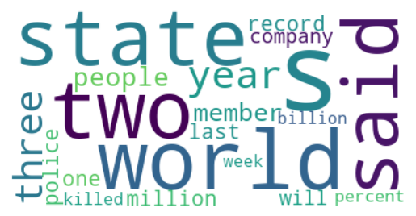

```python
premise_list = list(rte["premise"].values)
hypothesis_list = list(rte["hypothesis"].values)
premise, hypothesis = " ".join(premise_list), " ".join(hypothesis_list)
# Create and generate a word cloud image:
generate_word_cloud(premise)
```

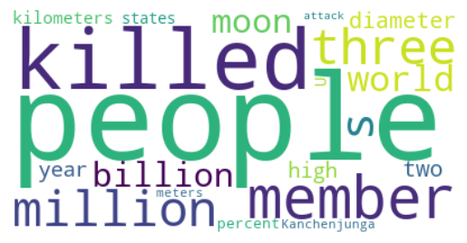

```python
generate_word_cloud(hypothesis)
```

Based on the most frequent unigrams in this dataset, RTE_Quant seems to be based on sentences extracted from news articles. We notice that 2 and 3 are very frequent quantities, alongside the "million" word.

### RedditNLI

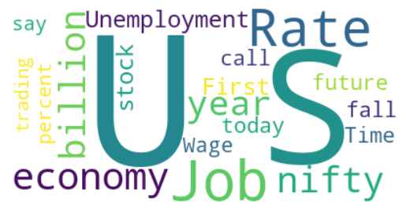

```python
premise_list = list(reddit["premise"].values)
hypothesis_list = list(reddit["hypothesis"].values)
premise, hypothesis = " ".join(premise_list), " ".join(hypothesis_list)
# Create and generate a word cloud image:
generate_word_cloud(premise)
```

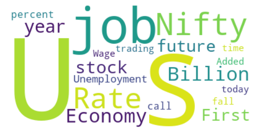

```python
generate_word_cloud(hypothesis)
```

### NewsNLI

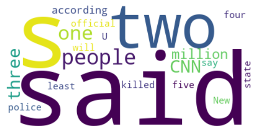

```python
premise_list = list(news["premise"].values)
hypothesis_list = list(news["hypothesis"].values)
premise, hypothesis = " ".join(premise_list), " ".join(hypothesis_list)
# Create and generate a word cloud image:
generate_word_cloud(premise)
```

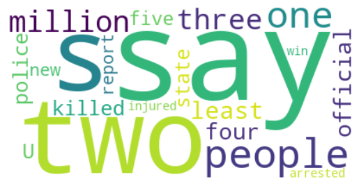

```python
generate_word_cloud(hypothesis)
```

For the NewsNLI dataset, we observe a combination of common quantities (one, two, three four, million) and words likely to be used in a news article (people, police, state, say, said, killed etc).

### AWPNLI

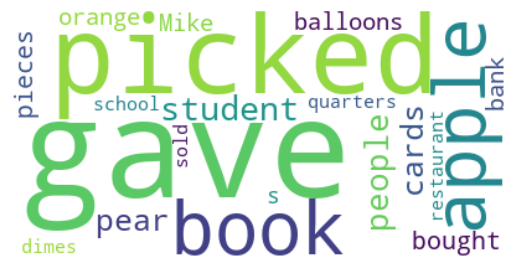

```python
premise_list = list(awp["premise"].values)
hypothesis_list = list(awp["hypothesis"].values)
premise, hypothesis = " ".join(premise_list), " ".join(hypothesis_list)
# Create and generate a word cloud image:
generate_word_cloud(premise)
```

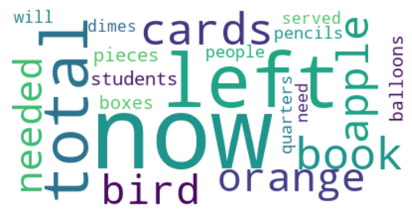

```python
generate_word_cloud(hypothesis)
```

As AWPNLI is a dataset based on Math word problems, the most frequent words inside it are nouns usuallu used as entities in this type of exercises (apples, book, orange). We also observe words which indicate operations like addition or subtraction (left, needed, gave, picked, bought).

### StressTest

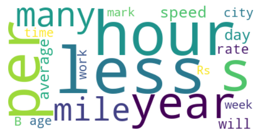

```python
premise_list = list(stress["premise"].values)
hypothesis_list = list(stress["hypothesis"].values)
premise, hypothesis = " ".join(premise_list), " ".join(hypothesis_list)
# Create and generate a word cloud image:
generate_word_cloud(premise)
```

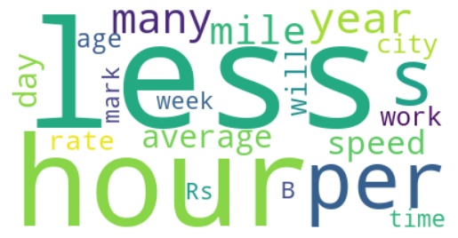

```python
generate_word_cloud(hypothesis)
```

Although the StressTest is also based on Math word problems, we notice a discrepancy between the word cloud for this set and those for AWPNLI. The StressTest seems to focus on problems with topics such as time (hour, day, age) and distance (mile, city, speed).

### Let's take a look at what type of textual quantifiers are in the datasets.

```python
# List of most common quantifier (this list is not exhaustive)
quantifiers = ["at least", "not less than", "no less than", "minimum of", "equal to or greater than", "no fewer than", "not fewer than", "not below", "at most", "no more than", "not more than", "more than", "maximum of", "equal to or less than", "no greater than", "not above", "less than or equal to", "not exceeding", "up to",
"greater than or equal to", "not fewer than", "down to", "less than", "below", "under", "lower than", "above", "over", "greater than", "as high as", "as little as", "exceeding", "around", "approximately", "roughly", "about", "near", "close to"]


def count_lookup_phrases(sentences):
    total_cnt, premise_count = 0, 0
    phrases_found = set()
    for phrase in quantifiers:
        for premise in sentences:
            premise_counted = False
            if phrase in premise:
                phrases_found.add(phrase)
                total_cnt += 1
                if not premise_counted:
                    premise_count += 1
    return total_cnt, premise_count, phrases_found
```

### AWPNLI

```python
print(count_lookup_phrases(list(awp["premise"].values)))
```

```
(18, 18, {'up to', 'over', 'around', 'about'})
```

```python
print(count_lookup_phrases(list(awp["hypothesis"].values)))
```

```
(8, 8, {'over'})
```

Only few of the AWPNLI samples have quantifiers. The focus of this dataset is on the model understanding it has to do calculations based on the quantities in the premise, so he can infer a quantity that must be compared to the one in the hypothesis. Moreover, given the synthetic source of the dataset (math word problems), the lack of diversity in the user quantifiers is also understandable.

### RedditNLI

```python
print(count_lookup_phrases(list(reddit["premise"].values)))
```

```
(41, 41, {'above', 'around', 'near', 'close to', 'under', 'at least', 'about', 'more than', 'down to', 'exceeding', 'over', 'below'})
```

```python
print(count_lookup_phrases(list(reddit["hypothesis"].values)))
```

```
(35, 35, {'above', 'around', 'near', 'under', 'at least', 'about', 'more than', 'down to', 'up to', 'over', 'below'})
```

Also for RedditNLI, a small fraction of the samples contain quantifiers. The focus in this dataset is on direct comparisons of the quantities and understanding if the quantities in the hypothesis are related to those in the premise and if they can be inferred or not.

### NewsNLI

```python
print(count_lookup_phrases(list(news["premise"].values)))
```

```
(296, 296, {'above', 'around', 'near', 'close to', 'under', 'at least', 'about', 'more than', 'down to', 'approximately', 'as high as', 'roughly', 'up to', 'over', 'below', 'less than'})
```

```python
print(count_lookup_phrases(list(news["hypothesis"].values)))
```

```
(170, 170, {'above', 'no more than', 'around', 'near', 'under', 'close to', 'at least', 'about', 'more than', 'down to', 'up to', 'over', 'below', 'less than'})
```

The NewsNLI dataset is more abundant in quantifiers. Given the nature of this dataset, namely news articles, the presence of quantifiers and their diversity is expected, since they play a key role in highlighting ideas and summarizing information, as well as making information easier to understand and/or remember (i.e. think of reporting the number "2473" compared to "at least 2400")

### RTE_Quant

```python
print(count_lookup_phrases(list(rte["premise"].values)))
```

```
(72, 72, {'above', 'around', 'near', 'under', 'at least', 'about', 'more than', 'greater than', 'roughly', 'up to', 'over', 'below', 'less than'})
```

```python
print(count_lookup_phrases(list(rte["hypothesis"].values)))
```

```
(25, 25, {'near', 'at least', 'about', 'more than', 'greater than', 'roughly', 'up to', 'over', 'less than'})
```

This dataset contains a relatively high ratio of samples with quantifiers (at least in the premise). Given the natural language source of this dataset, the presence of quantifiers is expected.

### StressTest

```python
print(count_lookup_phrases(list(stress["premise"].values)))
```

```
(3122, 3122, {'above', 'no more than', 'around', 'near', 'under', 'at least', 'maximum of', 'more than', 'about', 'approximately', 'greater than', 'minimum of', 'up to', 'at most', 'over', 'below', 'less than'})
```

```python
print(count_lookup_phrases(list(stress["hypothesis"].values)))
```

```
(4368, 4368, {'above', 'no more than', 'around', 'near', 'under', 'at least', 'maximum of', 'more than', 'about', 'approximately', 'greater than', 'minimum of', 'up to', 'at most', 'over', 'below', 'less than'})
```

This dataset contains a large fraction of samples with quantifiers. Given that this set is obtained from algebra word problems, the use of quantifiers and their diversity makes sense. The used quantifiers are basic ones, often encountered in math sentences.

### Finally, let's identify the baselines for each dataset, as well as a baseline for EQUATE as a whole

```python
datasets = [rte, news, reddit, awp, stress]
dataset_names = ["RTE_Quant", "NewsNLI", "RedditNLI", "AWPNLI", "StressTest"]

for dataset_df, dataset_name in zip(datasets, dataset_names):
    print(f"###############\n{dataset_name}")
    label_frequency = dataset_df['label'].value_counts(normalize=True).reset_index()  # find fraction of samples assigned to each label
    baseline_ratio = label_frequency['proportion'].max()
    label = label_frequency[label_frequency['proportion'] == baseline_ratio].iloc[0]["label"]
    print(f"Baseline: {round(baseline_ratio, 4)} (label: {label})")
```

```
###############
RTE_Quant
Baseline: 0.5783 (label: neutral)
###############
NewsNLI
Baseline: 0.5072 (label: entailment)
###############
RedditNLI
Baseline: 0.584 (label: entailment)
###############
AWPNLI
Baseline: 0.5 (label: entailment)
###############
StressTest
Baseline: 0.3333 (label: entailment)
```

```python
equate_df = pd.DataFrame()

for dataset in datasets:
    equate_df = pd.concat([equate_df, dataset], ignore_index=True)

print(equate_df.shape)
```

```
(9702, 30)
```

```python
label_frequency = equate_df['label'].value_counts(normalize=True).reset_index()  # find fraction of samples assigned to each label
baseline_ratio = label_frequency['proportion'].max()
label = label_frequency[label_frequency['proportion'] == baseline_ratio].iloc[0]["label"]
print(f"Baseline: {round(baseline_ratio, 4)} (label: {label})")
```

```
Baseline: 0.3711 (label: entailment)
```